# Ridging and Roping

Jacob Mokgadi

20/02/2022

# 1. Background

Ridging and Roping is a texture based defect that appears on the surface of a Ferritic type stainless Steel. During deep drawing and forming operations of stainless steel Ridging and Roping becomes evident on the surface of the steel and this makes the final product aesthetically displeasing to consumers. The purpose of this investigation was to determine the root cause of Ridging and Roping, while Isolating chemistry effects on grain orientation.

# 2. Definition and Quantifying the problem

- The defect has a 6.58% direct impact on yield loss
- 25% on Ferritic group non-conformance-to-rework
- additional three day contribution to the overall overdue (late material)
- Costing approximately R423 053 per month (R5,076,645 per annum)

# 3. Procedure

- The investigation will commence by keeping steel chemistry, and stabilizers at optimum levels
- Regressing other variables in order to find variables with the strongest correlation
- Establish leading indicators to detect possible formation
- Defect prevention in time

*Regressors*

- 3 main regression/classification models were used
- Decision Trees (Classification)
- Random Forests (Classifier on various subsets)
- Gradient Boosted modeling (regressor, combination of classifiers)

# 4. Load the necessary packages

```r
library(rpart)
library(caret)
```

```r
library(rpart.plot)
library(lattice)
library(RColorBrewer)
library(rattle)
library(randomForest)
library(dplyr)
library(tidyverse)
library(doParallel)
library(ggplot2)
library(iterators)
library(xlsx)
library(readxl)
library(readr)
library(stringi)
library(stringr)
library(party)
library(partykit)
library(xgboost)
library(pdp)
library(gbm)
```

# 5. Load and view the data

```r
Mills_data_441 <- read_excel("G:/Shared drives/Business Improvement/Projects/441 R&R project/Data/Millsred441QC.xlsx")

Mills_data_441
```

```
## # A tibble: 437 x 19
##    Product_No AP1_Temp_group Roping TotRed WaflowZone1_S WaflowZone1_I_O
##         <dbl> <chr>          <chr>   <dbl>         <dbl>           <dbl>
##  1    4348613 1010           YES     0.599          89.0            435.
##  2    4348622 1010           YES     0.487          89.0            435
##  3    4348664 1010           NO      0.647          89.0            435.
##  4    4348574 1010           NO      0.504          89.0            435.
##  5    4348563 1010           YES     0.622          89.0            435.
##  6    4348564 1010           NO      0.671          89.0            435.
##  7    4348593 1010           NO      0.622          89.0            435.
##  8    4348591 1010           NO      0.573          72.0            329.
##  9    4348673 1010           NO      0.679          89.0            435.
## 10    4348584 1010           YES     0.513          89              435.
## # ... with 427 more rows, and 13 more variables: WaflowZone2_I_O <dbl>,
## #   WaflowZone3_I_O <dbl>, WaflowZone4_I <dbl>, WaflowZone4_O <dbl>,
## #   WaflowZone5_I <dbl>, WaflowZone5_O <dbl>, WaflowZone6_I <dbl>,
## #   WaflowZone7_I <dbl>, WF_Sum <dbl>, SUM_Wet <dbl>, Flow <dbl>, SWF <dbl>,
## #   Cooling_system <chr>
```

# 5.1 Cleaning the data

Take out unnecessary columns

```r
Mills_data_441%>%
  select(-c(Product_No, SUM_Wet, SWF,WF_Sum,AP1_Temp_group))%>%
  purrr::discard(~sum(is.na(.x))/length(.x)* 100 >=50)%>%
  drop_na()->
  Mills_data_441
Mills_data_441
```

```
## # A tibble: 428 x 14
##    Roping TotRed WaflowZone1_S WaflowZone1_I_O WaflowZone2_I_O WaflowZone3_I_O
##    <chr>   <dbl>         <dbl>           <dbl>           <dbl>           <dbl>
##  1 YES     0.599          89.0            435.            474.            248.
##  2 YES     0.487          89.0            435             495.            248.
##  3 NO      0.647          89.0            435.            487.            245.
##  4 NO      0.504          89.0            435.            460.            244.
##  5 YES     0.622          89.0            435.            490.            246.
##  6 NO      0.671          89.0            435.            471.            237.
##  7 NO      0.622          89.0            435.            481.            244.
##  8 NO      0.573          72.0            329.            372.            183.
##  9 NO      0.679          89.0            435.            494.            252.
## 10 YES     0.513          89              435.            470.            241.
## # ... with 418 more rows, and 8 more variables: WaflowZone4_I <dbl>,
## #   WaflowZone4_O <dbl>, WaflowZone5_I <dbl>, WaflowZone5_O <dbl>,
## #   WaflowZone6_I <dbl>, WaflowZone7_I <dbl>, Flow <dbl>, Cooling_system <chr>
```

```r
Mills_data_441<-group_by(Mills_data_441,Roping)%>%sample_n(194)
table(Mills_data_441$Roping)
```

```
##
##  NO YES
## 194 194
```

```r
Mills_data_441
```

```
## # A tibble: 388 x 14
## # Groups:   Roping [2]
##    Roping TotRed WaflowZone1_S WaflowZone1_I_O WaflowZone2_I_O WaflowZone3_I_O
##    <chr>   <dbl>         <dbl>           <dbl>           <dbl>           <dbl>
##  1 NO      0.765          86.5            418.            458.            234.
##  2 NO      0.599          89.0            435.            474.            248.
##  3 NO      0.571          63.8            286.            328.            196.
##  4 NO      0.677          89.0            435.            489.            248.
##  5 NO      0.650          67.8            312.            358.            194.
##  6 NO      0.679          55.4            233.            339.            198.
##  7 NO      0.579          89.0            435.            462.            240.
##  8 NO      0.608          95.0            466.            480.            256.
##  9 NO      0.676          89.0            435.            455.            243.
## 10 NO      0.695          89.0            435.            464.            248.
## # ... with 378 more rows, and 8 more variables: WaflowZone4_I <dbl>,
## #   WaflowZone4_O <dbl>, WaflowZone5_I <dbl>, WaflowZone5_O <dbl>,
## #   WaflowZone6_I <dbl>, WaflowZone7_I <dbl>, Flow <dbl>, Cooling_system <chr>
```

# 5.2 Data partitioning

The next step is to partition the data set into training and testing portions, this helps with validating predictors. A good partition is based on 80/20 (being 80% of the data set reserved for training and 20% for testing)

```r
inTraining<-createDataPartition(y=Mills_data_441$Roping,p=0.8,list=FALSE)
myTraining<-Mills_data_441[inTraining,]
myTesting<-Mills_data_441[-inTraining,]

dim(myTraining);dim(myTesting)
```

```
## [1] 312  14
```

```
## [1] 76 14
```

# 6.1 Decision trees for prediction

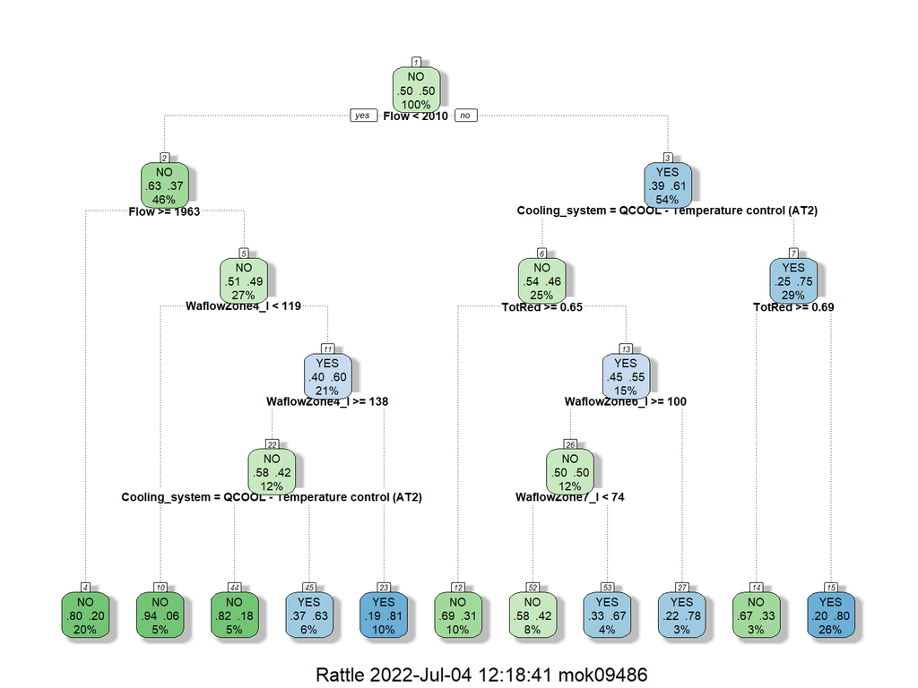

```r
modFitDC <- rpart(Roping~., data=myTraining, method="class")
fancyRpartPlot(modFitDC,cex=0.6)
```

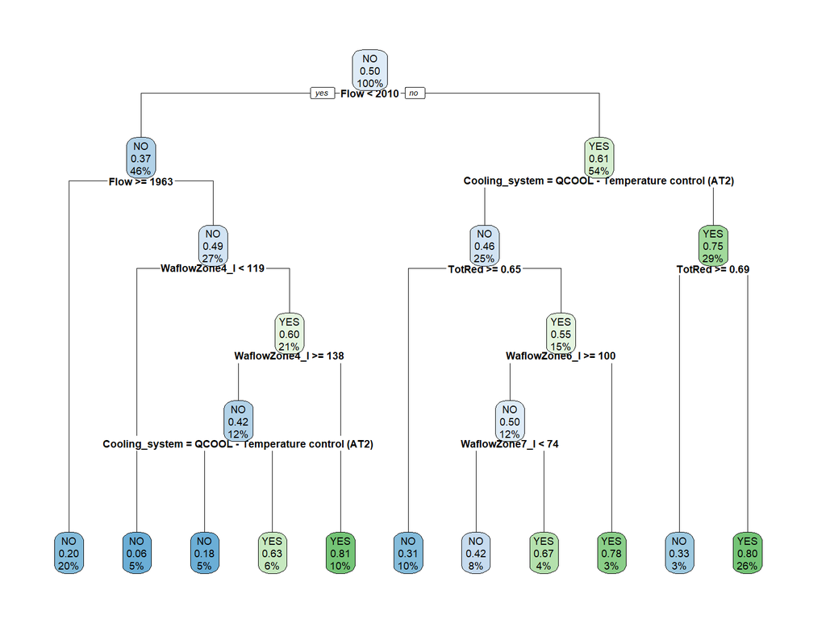

```r
rpart.plot(modFitDC,cex=0.6)
```

# Confusion matrix to test the results

```r
predictions_DC <- predict(modFitDC, myTesting, type = "class")
myTesting$Roping<-as.factor(myTesting$Roping)
confusionMatrix(predictions_DC, myTesting$Roping)
```

```
## Confusion Matrix and Statistics
##
##           Reference
## Prediction NO YES
##        NO  23  10
##        YES 15  28
##
##                Accuracy : 0.6711
##                  95% CI : (0.5537, 0.7746)
##     No Information Rate : 0.5
##     P-Value [Acc > NIR] : 0.001918
##
##                   Kappa : 0.3421
##
##  Mcnemar's Test P-Value : 0.423711
##
##             Sensitivity : 0.6053
##             Specificity : 0.7368
##          Pos Pred Value : 0.6970
##          Neg Pred Value : 0.6512
##              Prevalence : 0.5000
##          Detection Rate : 0.3026
##    Detection Prevalence : 0.4342
##       Balanced Accuracy : 0.6711
##
##        'Positive' Class : NO
##
```

# 6.1 Random forests

```r
modFitRM <- randomForest(as.factor(Roping) ~. ,data=myTraining,method="rf")
```

Predicting sample error

```r
predictionsRM <- predict(modFitRM, myTesting, type = "class")
```

Testing the results with a confusion matrix

```r
conf_matrx_2<-confusionMatrix(predictionsRM, myTesting$Roping)
conf_matrx_2
```

```
## Confusion Matrix and Statistics
##
##           Reference
## Prediction NO YES
##        NO  23  12
##        YES 15  26
##
##                Accuracy : 0.6447
##                  95% CI : (0.5266, 0.7512)
##     No Information Rate : 0.5
##     P-Value [Acc > NIR] : 0.00772
##
##                   Kappa : 0.2895
##
##  Mcnemar's Test P-Value : 0.70031
##
##             Sensitivity : 0.6053
##             Specificity : 0.6842
##          Pos Pred Value : 0.6571
##          Neg Pred Value : 0.6341
##              Prevalence : 0.5000
##          Detection Rate : 0.3026
##    Detection Prevalence : 0.4605
##       Balanced Accuracy : 0.6447
##
##        'Positive' Class : NO
##
```

Plotting the results

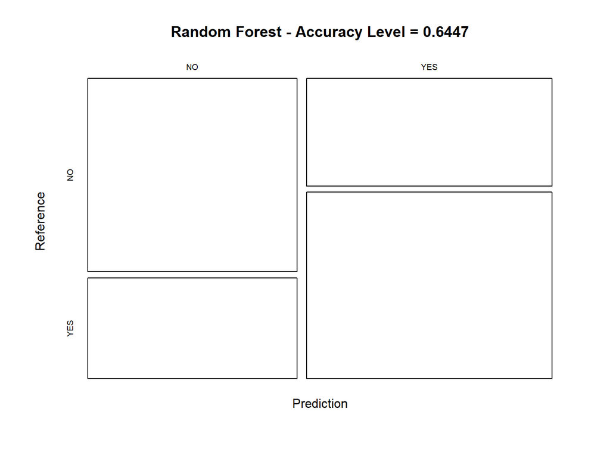

```r
plot(conf_matrx_2$table, col = conf_matrx_2$byClass,
     main = paste("Random Forest - Accuracy Level =",
                  round(conf_matrx_2$overall['Accuracy'], 4)))
```

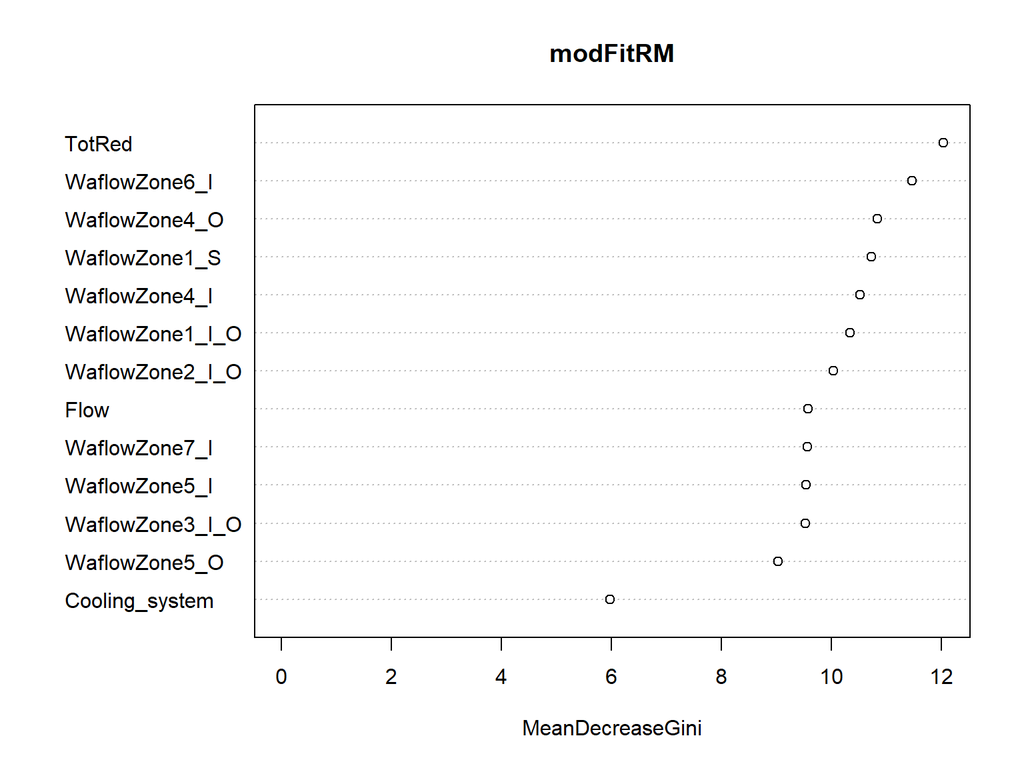

```r
varImpPlot(modFitRM)
```